# Humor Vs. Horror

William Lovejoy

4/11/2022

## Core Question

Comedy and horror are often described as incredibly similar. To be successful, both need an understanding of the core emotional drivers in human psychology. And both tend to rely on subverting expectations to achieve their goals. With this in mind, how similar are the sentiments percieved in the respective texts of a comedy and a horror book? And how similar might the reviews of those books be?

To start with, our books were chosen from the 2021 Goodreads Choice Awards for comedy and horror, and the comments were scraped from the books’ Goodreads page.

For comedy: we have *Broken* by Jenny Lawson For horror: we have *The Final Girl Support Group* by Grady Hendrix

```r
horrorURL <- "https://www.goodreads.com/book/show/55829194-the-final-girl-support-group?from_choice=true"
humorURL <-  "https://www.goodreads.com/book/show/54305363-broken?from_choice=true"
horrorPage <- read_html(horrorURL)
humorPage <- read_html(humorURL)


horrorCommentNodes <- html_nodes(horrorPage, '#bookReviews .readable span')
horrorComments <- html_text(horrorCommentNodes)
horrorComments <- gsub("\\\\", "", gsub("’", "'", horrorComments))

humorCommentNodes <- html_nodes(humorPage, '#bookReviews .readable span')
humorComments <- html_text(humorCommentNodes)
humorComments <- gsub("\\\\", "", gsub("’", "'", humorComments))
```

Our scraped comment data had some text issues that needed to be cleaned, but we were left with 58 comments for each book. Next up, we can add the book title and comments to dataframes and then bind them together with rbind().

```r
df1 <- data.frame(CommentNumber = 1:length(horrorComments),
                  Book = "The Final Girl Support Group",
                  Comments = horrorComments)
df2 <- data.frame(CommentNumber = 1:length(humorComments),
                  Book = "Broken",
                  Comments = humorComments)

df <- rbind(df1, df2)
```

## Comment EDA

Now that our comments are loaded, sorted, and labeled: we can unnest them and make quick wordclouds and run our sentiment analysis using the Bing et al. lexicon.

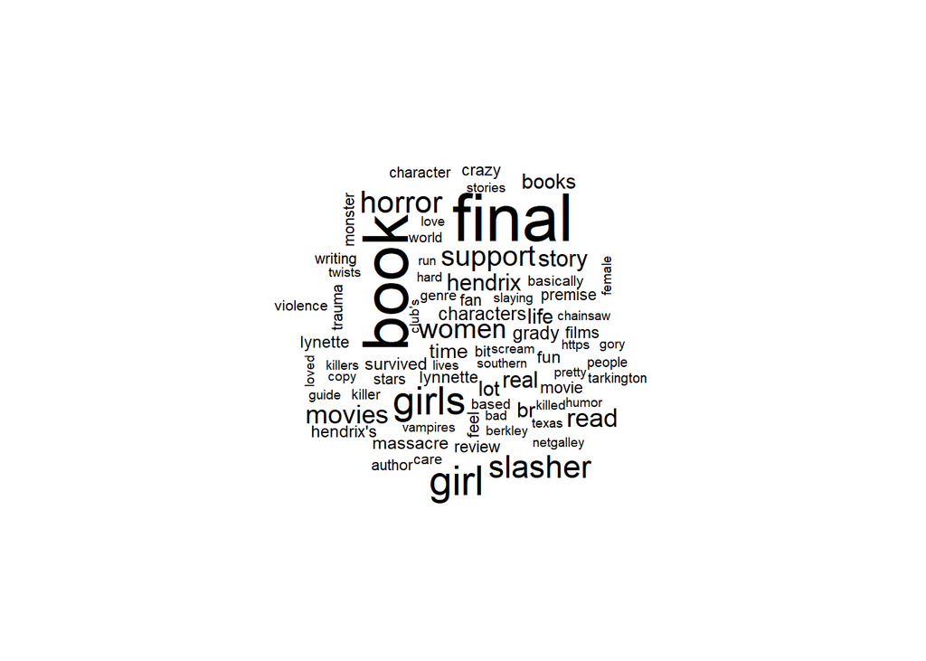

```r
tidy_df <- df %>%
  unnest_tokens(word, Comments)

subset(tidy_df, Book == "The Final Girl Support Group")  %>%
  anti_join(stop_words) %>%
  count(word) %>%
  with(wordcloud(word, n, scale = c(3, .4), max.words = 75))
```

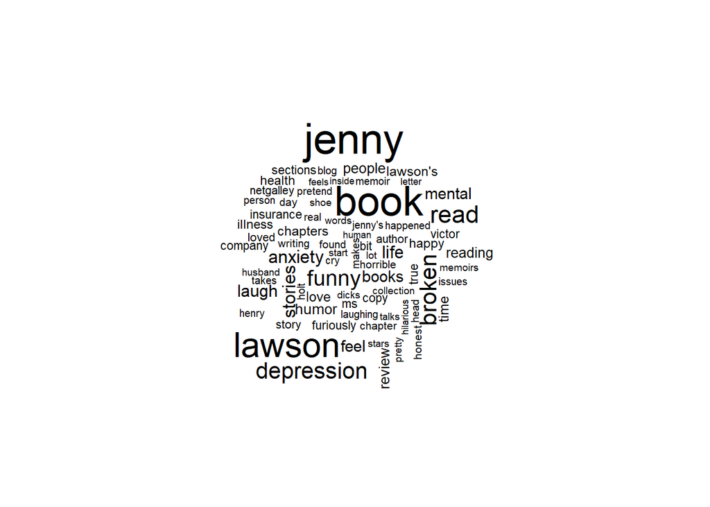

```r
subset(tidy_df, Book == "Broken")  %>%
  anti_join(stop_words) %>%
  count(word) %>%
  with(wordcloud(word, n, scale = c(2.5, .4), max.words = 75))
```

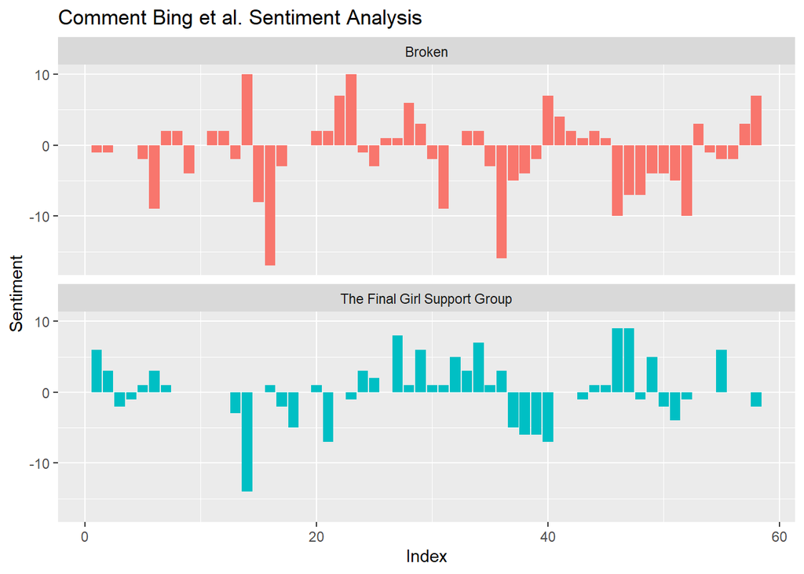

```r
df_sentiments <- tidy_df %>%
  inner_join(get_sentiments("bing")) %>%
  group_by(Book) %>%
  count(index = CommentNumber, sentiment) %>%
  pivot_wider(names_from = sentiment, values_from = n, values_fill = 0) %>%
  mutate(sentiment = positive - negative) %>%
  ungroup()

ggplot(df_sentiments, aes(x = index, y = sentiment, fill = Book)) +
  geom_col(show.legend = FALSE) + facet_wrap(~ Book, ncol = 1) +
  xlab("Index") + ylab("Sentiment") +
  labs(title = "Comment Bing et al. Sentiment Analysis")
```

We can see that comments about *Broken* tend to mention the author, while *The Final Girl Support Group* tends to mention the book. We can also see fairly even distributions of sentiments between the books, with each column in the plot representing an individual comment. So now we can get into the texts themselves.

## Text Analysis

We start by loading in our text files, removing extra symbols, and changing apostrophes to single quotes. I also removed the lines with information about the publisher and copywrites because they won’t be needed for the analysis. Then we add in the book title to our dataframes and use head() to make sure that both dataframes look clean.

```r
broken <- read_delim("C:\\Users\\William Lovejoy\\Documents\\Codes\\R\\DataScience\\Epubs\\broken.txt",
                     delim = "\n")
girl <- read_delim("C:\\Users\\William Lovejoy\\Documents\\Codes\\R\\DataScience\\Epubs\\the-final-girl-support-group.txt",
                   delim = "\n")
girl$Text <- gsub("\t", "", girl$Text)

broken <- broken %>%
  mutate(linenumber = row_number()) %>%
  ungroup()

girl <- girl %>%
  mutate(linenumber = row_number()) %>%
  ungroup()

broken_tidy <- broken %>%
  unnest_tokens(word, Text)
broken_tidy$word <- gsub("’", "'", broken_tidy$word)

girl_tidy <- girl %>%
  unnest_tokens(word, Text)
girl_tidy$word <- gsub("’", "'", girl_tidy$word)

girl_tidy <- girl_tidy[-c(1:106), ]
broken_tidy <- broken_tidy[-c(6:113), ]
girl_tidy$Book <- "The Final Girl Support Group"
broken_tidy$Book <- "Broken"

head(girl_tidy)
```

```
## # A tibble: 6 x 3
##   linenumber word    Book
##        <int> <chr>   <chr>
## 1          9 title   The Final Girl Support Group
## 2          9 the     The Final Girl Support Group
## 3          9 final   The Final Girl Support Group
## 4          9 girl    The Final Girl Support Group
## 5          9 support The Final Girl Support Group
## 6          9 group   The Final Girl Support Group
```

```r
head(broken_tidy)
```

```
## # A tibble: 6 x 3
##   linenumber word      Book
##        <int> <chr>     <chr>
## 1          1 begin     Broken
## 2          1 reading   Broken
## 3          2 table     Broken
## 4          2 of        Broken
## 5          2 contents  Broken
## 6         14 dedicated Broken
```

### Graphics

Now that we have the texts loaded in and unnested into our tokens, we can being making graphics.

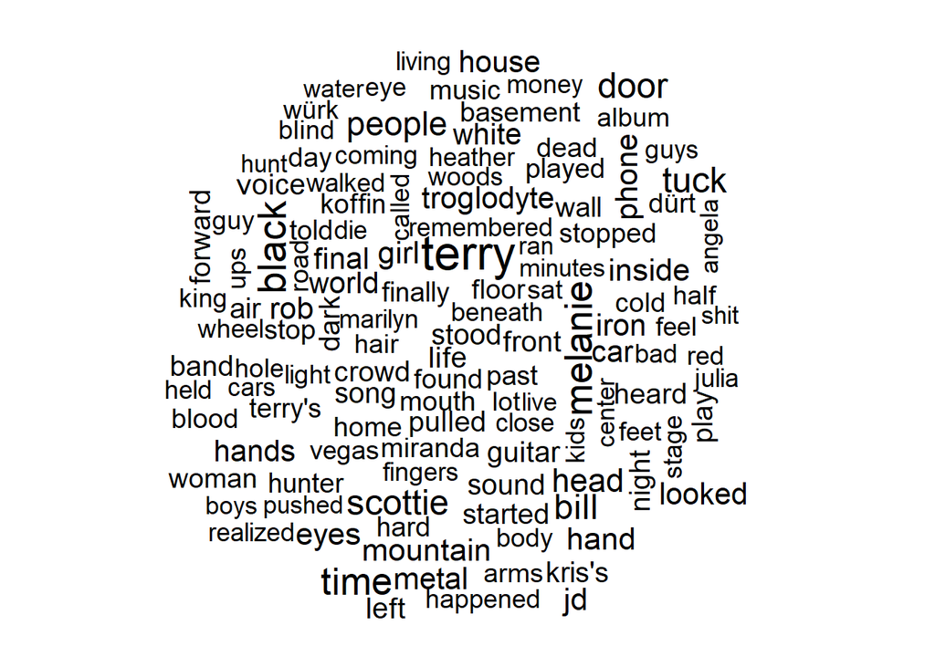

```r
girl_tidy %>%
  anti_join(stop_words) %>%
  count(word) %>%
  with(wordcloud(word, n, scale = c(5, 1), max.words = 125))
```

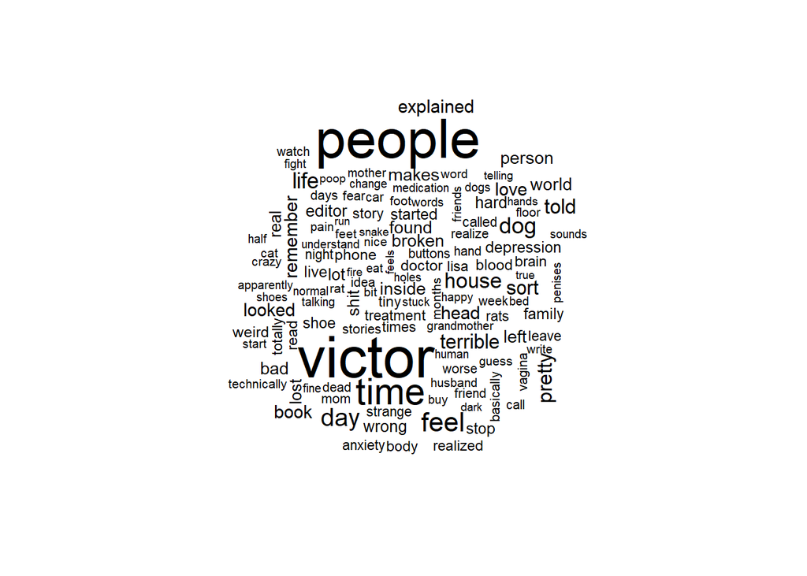

```r
broken_tidy %>%
  anti_join(stop_words) %>%
  count(word) %>%
  with(wordcloud(word, n, scale = c(3, .3), max.words = 125))
```

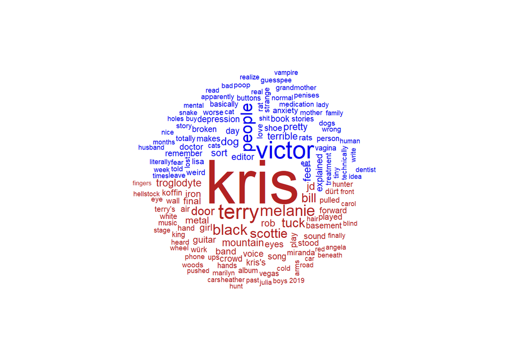

```r
texts <- rbind(girl_tidy, broken_tidy)
texts$Book <- as.factor(texts$Book)

texts %>%
  anti_join(stop_words) %>%
  count(word, Book) %>%
  acast(word ~ Book, value.var = "n", fill = 0) %>%
  comparison.cloud(random.order = FALSE, scale = c(5, .4), colors = c("blue2", "firebrick"),
                   max.words = 150)
```

Our individual wordclouds’ let us see the more common words in each book, while our comparative cloud let’s us look at word frequency between the two books. We can see that frequent words in *The Final Girl Support Group* tend to be names, whereas *Broken* has a largely balanced frequency distribution among varied topics.

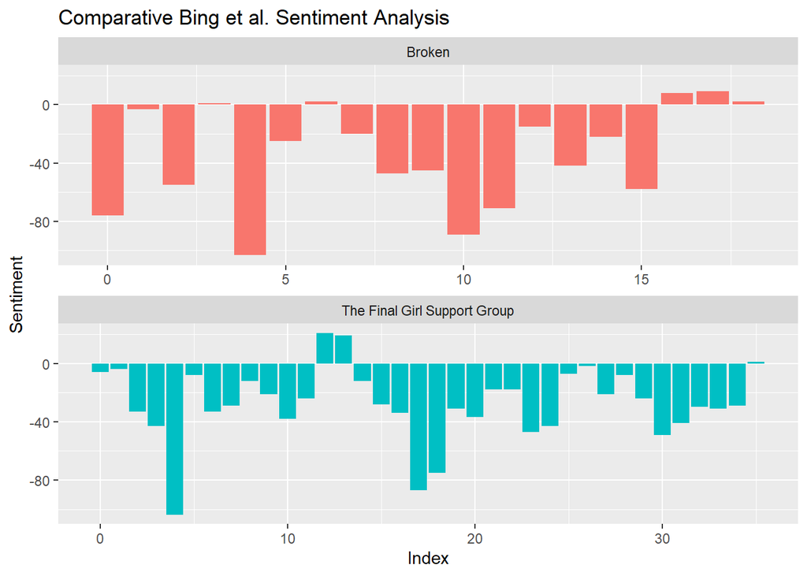

```r
texts_sentiment <- texts %>%
  inner_join(get_sentiments("bing")) %>%
  group_by(Book) %>%
  count(index = linenumber %/% 80, sentiment) %>%
  pivot_wider(names_from = sentiment, values_from = n, values_fill = 0) %>%
  mutate(sentiment = positive - negative) %>%
  ungroup()

ggplot(texts_sentiment, aes(x = index, y = sentiment, fill = Book)) +
  geom_col(show.legend = FALSE) +
  facet_wrap(~ Book, ncol = 1, scales = "free_x") +
  xlab("Index") + ylab("Sentiment") +
  labs(title = "Comparative Bing et al. Sentiment Analysis")
```

Both books contain words commonly perceived as negative for the bulk of their stories. There are only 5 instances in *Broken* of a section having an overall positive sentiment, and 3 in *The Final Girl Support Group*. The sentimental rise and fall of each book even occurs in similar places along the story.